# Práctica - Suavización

Mike

2023-03-14

# Práctica de suavización exponencial

Iniciamos de la menera estandar:

```r
rm(list=ls())

setwd("~/Documents/suavizacion")

library(forecast)
library(tidyverse)
library(readxl)
```

Vamos analizar las ventas de coca-cola, netflix y walmart

```r
ko <- read_excel("coca.xlsx")
wal <- read_excel("walmart.xlsx")
netflix <- read_excel("netflix.xlsx")

ko <- ts(ko$`Coca-Cola Sales`, start = 1980, frequency = 1)
wal <- ts(wal$`Walmart Sales`, start = 1981, frequency = 1)
netflix <- ts(netflix$`Netflix Sales`, start = 2002, frequency = 1)
```

Hacemos un analisis grafico

## Coca-cola

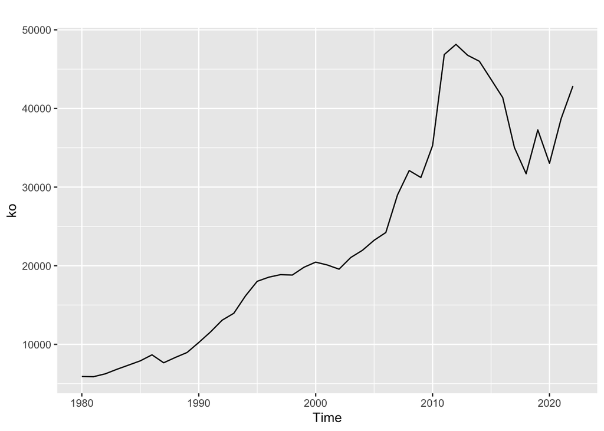

```r
autoplot(ko)
```

Para la serie de coca-cola, como tiene tendencia, se recomendia el uso del método de holt o holt amortiguado

Realizamos el pronostico de h periodos:

```r
pronostico_ko <- holt(ko, h=10)

pronostico_ko2 <- holt(ko, h=10, damped = TRUE)
```

Analizamos los resultados: Pedimos la tabla de pronostico, se muestra la estimación puntual y las estimaciones por intervalo (80% al 95% de manera predeterminada).

```r
pronostico_ko
```

```
##      Point Forecast    Lo 80    Hi 80    Lo 95    Hi 95
## 2023       43587.71 39786.07 47389.36 37773.60 49401.83
## 2024       44335.58 38959.90 49711.27 36114.18 52556.98
## 2025       45083.45 38499.66 51667.25 35014.41 55152.50
## 2026       45831.32 38228.85 53433.80 34204.34 57458.30
## 2027       46579.19 38079.09 55079.29 33579.41 59578.98
## 2028       47327.06 38015.31 56638.82 33085.96 61568.16
## 2029       48074.93 38016.67 58133.20 32692.14 63457.72
## 2030       48822.80 38069.59 59576.01 32377.19 65268.42
## 2031       49570.67 38164.66 60976.69 32126.68 67014.67
## 2032       50318.54 38294.99 62342.09 31930.11 68706.98
```

Podemos analizar también los parámetros de la estimación, las constantes de suavizacion y el error.

```r
summary(pronostico_ko)
```

```
##
## Forecast method: Holt's method
##
## Model Information:
## Holt's method
##
## Call:
##  holt(y = ko, h = 10)
##
##   Smoothing parameters:
##     alpha = 0.9997
##     beta  = 1e-04
##
##   Initial states:
##     l = 5453.5353
##     b = 747.3452
##
##   sigma:  2966.439
##
##      AIC     AICc      BIC
## 855.1133 856.7349 863.9193
##
## Error measures:
##                   ME     RMSE      MAE        MPE     MAPE      MASE      ACF1
## Training set 122.016 2825.098 1772.375 -0.5492149 6.575582 0.8855129 0.1810455
##
## Forecasts:
##      Point Forecast    Lo 80    Hi 80    Lo 95    Hi 95
## 2023       43587.71 39786.07 47389.36 37773.60 49401.83
## 2024       44335.58 38959.90 49711.27 36114.18 52556.98
## 2025       45083.45 38499.66 51667.25 35014.41 55152.50
## 2026       45831.32 38228.85 53433.80 34204.34 57458.30
## 2027       46579.19 38079.09 55079.29 33579.41 59578.98
## 2028       47327.06 38015.31 56638.82 33085.96 61568.16
## 2029       48074.93 38016.67 58133.20 32692.14 63457.72
## 2030       48822.80 38069.59 59576.01 32377.19 65268.42
## 2031       49570.67 38164.66 60976.69 32126.68 67014.67
## 2032       50318.54 38294.99 62342.09 31930.11 68706.98
```

Por ejemplo, en nuestra empresa se pide utilizar siempre un alfa de 0.8

Reemplazo la estimación de holt

```r
pronostico_ko <- holt(ko, h=10, alpha = 0.8)

pronostico_ko
```

```
##      Point Forecast    Lo 80     Hi 80    Lo 95     Hi 95
## 2023       45787.13 41652.53  49921.73 39463.80  52110.46
## 2024       49390.63 42676.69  56104.57 39122.54  59658.72
## 2025       52994.13 43096.76  62891.51 37857.40  68130.86
## 2026       56597.63 43047.88  70147.39 35875.08  77320.19
## 2027       60201.14 42598.64  77803.63 33280.45  87121.83
## 2028       63804.64 41791.65  85817.63 30138.68  97470.60
## 2029       67408.14 40656.97  94159.31 26495.75 108320.53
## 2030       71011.64 39217.52 102805.76 22386.73 119636.55
## 2031       74615.15 37491.68 111738.61 17839.70 131390.59
## 2032       78218.65 35494.65 120942.65 12877.93 143559.37
```

Además, queremos el intervalo de confianza, solamente al 99%.

```r
pronostico_ko <- holt(ko, h=10, alpha = 0.8, level = 0.99)

pronostico_ko
```

```
##      Point Forecast         Lo 99     Hi 99
## 2023       45787.13 37476.8663081  54097.39
## 2024       49390.63 35896.0757649  62885.18
## 2025       52994.13 33101.0951296  72887.17
## 2026       56597.63 29363.5793336  83831.69
## 2027       60201.14 24821.3541231  95580.92
## 2028       63804.64 19560.0662306 108049.21
## 2029       67408.14 13640.1499988 121176.13
## 2030       71011.64  7107.6801680 134915.61
## 2031       74615.15    -0.4335786 149230.73
## 2032       78218.65 -7653.6109088 164090.91
```

Gráfica del pronóstico, agregamos la opción “PI=FALSE” para ocultar los intervalos de confianza del pronóstico.

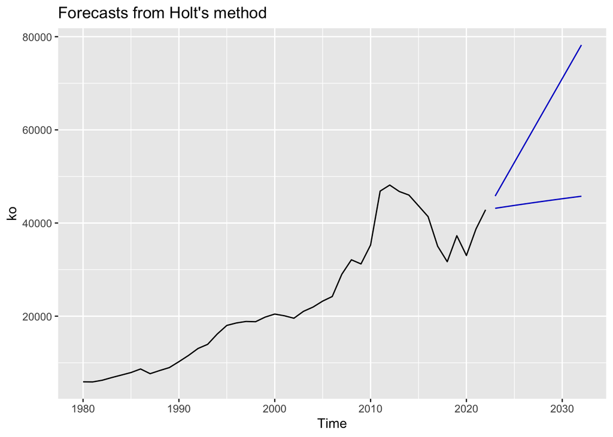

```r
autoplot(pronostico_ko, PI=FALSE)+
  autolayer(pronostico_ko2, PI=FALSE)
```

# Walmart

Analizar las ventas de esta empresa y decidir que método (o métodos) utilizar para pronosticar los siguientes 10 años.

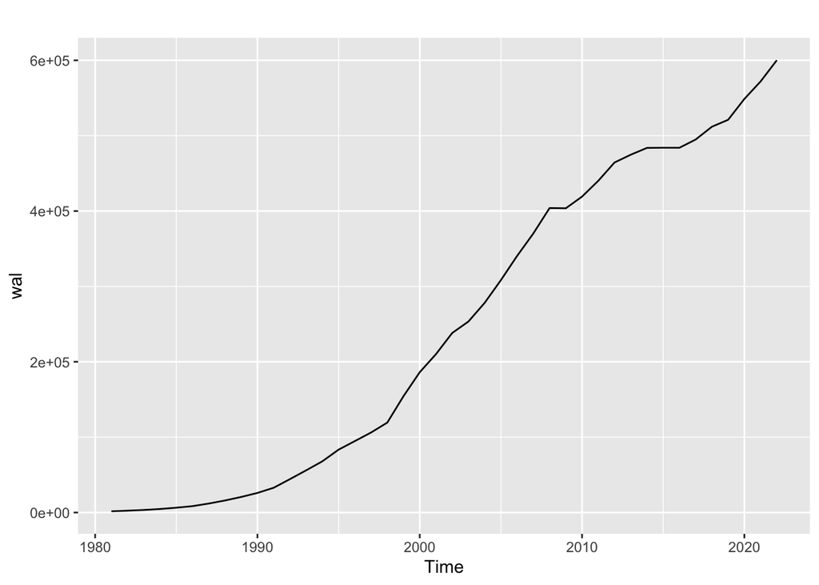

```r
autoplot(wal)
```

# Netflix

Analizar las ventas de esta empresa y decidir que método (o métodos) utilizar para pronosticar los siguientes 10 años.

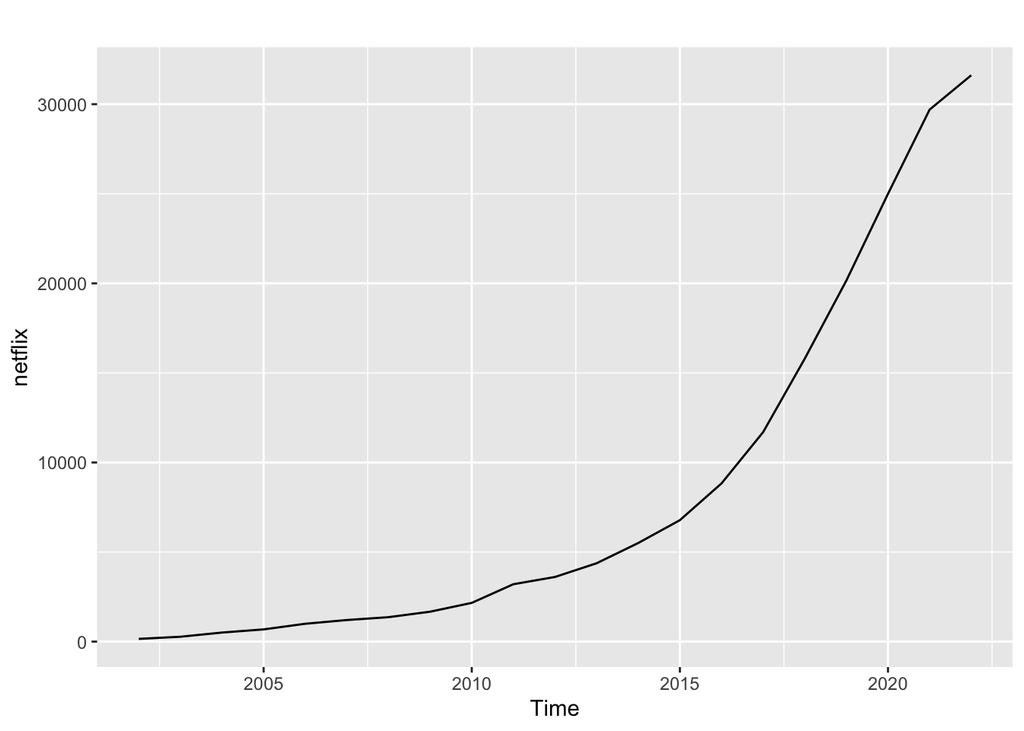

```r
autoplot(netflix)
```